# Aula 12 - Econometria de Séries Temporais

João Ricardo F. de Lima

23 de maio de 2022.

# 1 VEC - Vetorial Autorregressivo com correção de erro

Um dos pressupostos para se estimar um modelo VAR é que as variáveis sejam estacionárias. Isso significa que se essa hipótese for violada, é necessário realizar outro tipo de análise, verificando a existência de **cointegração** entre duas ou mais variáveis, isto é, se existe uma relação de longo-prazo entre elas.

Se as séries não forem estacionárias, as mesmas podem estar relacionadas ao longo do tempo. Se for esse o caso, diz-se que as séries possuem uma tendência comum, o que nos permite avaliar a relação entre elas.

Sejam $Y_t$, $X_t$ e $Z_t$ três séries temporais e a seguinte relação de interesse:

$$Y_t=\alpha+\beta X_t+ \gamma Z_t + \epsilon_t$$

Neste caso tem que se considerar as seguintes possibilidades:

1. Se $Y_t$, $X_t$ e $Z_t$ são estacionárias, estima-se a equação acima em nível
2. Se $Y_t$, $X_t$ e $Z_t$ são não estacionárias, tem-se outras possibilidades:

Se $Y_t$, $X_t$ e $Z_t$ são não estacionárias mas co-integradas, deve-se estimar um Modelo de Correçao de Erro (MCE) na forma uni ou multivariada dado por

$$\Delta Y_t=\alpha+\beta \Delta X_t+ \gamma \Delta Z_t +\lambda
\hat{\epsilon}_{t-1}+u_t$$

em que $\hat{\epsilon}_{t-1}$ são os resíduos da equação do slide anterior.

Se $Y_t$, $X_t$ e $Z_t$ são não estacionárias e não co-integradas, deve-se ajustar a equação do slide anterior em primeiras diferenças, ou seja,

$$\Delta Y_t=\alpha+\beta \Delta X_t+ \gamma \Delta Z_t + v_t$$

## 1.1 Co-integração - Relações de Equilíbrio de Longo Prazo

A combinação linear é dada por

$$Z_t=a_1Y_{1t}+a_2Y_{2t}+a_3Y_{3t}+\dots+a_kY_{kt}$$

O vetor $a=[a_1 \quad a_2\quad a_3\quad \dots\quad a_k]'$ é chamado de “vetor de co-integração”. Os casos de interesse para as relações econômicas são quando a combinação linear é estacionária, ou seja, I(0).

Considere $Y_t \sim I(1)$, $X_t \sim I(1)$ e $Z_t \sim I(1)$ e a relação:

$$Y_t=\beta_0+\beta_1 X_t+ \beta_2 Z_t$$

esta relação estará em equilíbrio de longo prazo se $0=Y_t-\beta_0-\beta_1 X_t- \beta_2 Z_t$, sendo que para o equilíbrio existir e ter significado econômico, o resíduo deve ser estacionário.

Assim, com $Y_t \sim I(1)$, $X_t \sim I(1)$ e $Z_t \sim I(1)$ e $\epsilon_t=Y_t-\beta_0-\beta_1 X_t- \beta_2 Z_t \sim I(0)$, tem-se que as três séries são co-integradas com vetor de cointegração dado por

$$\beta=[1 \quad -\beta_0\quad -\beta_1\quad -\beta_2]'$$

## 1.2 Vetores de Co-integração

Os vetores de co-integração (CI) não são únicos. Podem existir várias combinações lineares estacionárias devido a existência de vários vetores de CI. O número de vetores de CI depende do número de variáveis envolvidas. Tem-se:

1. Caso de 2 variáveis: com 2 variáveis existe somente uma combinação estacionária entre as variáveis que representa uma relação de equilíbrio de longo prazo;
2. Caso de k variáveis: com k variáveis existem até k-1 vetores de co-integração linearmente independentes.

## 1.3 Rank de Co-integração

O rank de CI (r) é o número de vetores de CI linearmente independentes. Para k variáveis de mesma ordem de integração e co-integradas, $1 \le r \le k-1$.

## 1.4 Testes de Co-Integração - Caso Multivariado

Para se testar co-integração no caso Multivariado, suponha K variáveis todas integradas de mesma ordem I(1). Sendo as variáveis todas I(1), a existência de combinações lineares I(0) entre elas indica que estas variáveis são co-integradas. Estas combinações lineares governam o comportamento de equilíbrio de longo prazo. Em geral, existem $r\le K-1$ combinações lineares independentes que são as relações de CI e é necessário encontrar o valor de r;

Se r=K as variáveis são I(0). Se r=0, não existe relação de longo prazo entre as variáveis. Se $1 \le r \le k-1$, existem de 1 até k-1 vetores de co-integração e é necessário definir o valor de r.

A metodologia para se determinar o número de vetores de CI e estimar as relações de CI é baseada na estimação de um **Modelo Vetorial Autorregressivo** conhecido como modelo VAR, que foi desenvolvida por Johansen.

### 1.4.1 Teste de Co-Integração de Johansen

Considere um VAR(2) com k variáveis, todas possuindo raiz unitária:

$$Y_t=\alpha+\theta_1Y_{t-1}+\theta_2Y_{t-2}+\epsilon_t$$

É possível subtrair $Y_{t-1}$ dos dois lados nesta equação e rearranjar os termos para obter:

$$\Delta Y_t=\alpha+(\theta_1+\theta_2-I)Y_{t-1}-\theta_2 \Delta
y_{t-1}+\epsilon_t$$

com um pouco mais de álgebra é possível reescrever um VAR(p) com k variáveis como um VEC (VAR Reparametrizado) da forma

$$\Delta Y_t=\alpha+\Pi Y_{t-1}+ \sum_{i=1}^{p-1}\Gamma_i\Delta
y_{t-i}+\epsilon_t$$

em que

$$\Pi=\sum_{j=1}^{p}\theta_j-I$$

e

$$\Gamma_i=- \sum_{j=i+1}^{p}\theta_j$$

$\Pi$ é a matriz dos coeficientes das relações de cointegração; $\Gamma$ é a matriz dos coeficientes da variável $Y$ diferenciada defasadas.

A diferença do VEC para o VAR é o termo de correção de erro $\Pi Y_{t-1}$. Engle e Granger (1987) mostraram que $\Pi$ tem rank r, $0 \le r <K$, em que r é o número de vetores de cointegração linearmente independentes entre os elementos do vetor $Y_t$. Assim, não se pode simplesmente estimar um VAR em $\Delta Y_t$ quando existe relações de cointegração pois se estaria omitindo $\Pi Y_{t-1}$. Se não existem relações de cointegração entre os elementos de $Y_t$, o rank de $\Pi$ é 0 e o termo $\Pi Y_{t-1}$ desaparece.

Se rank $(\Pi)=r<k$, pode-se mostrar que existem matrizes $\psi_{kxr}$ e $\beta_{kxr}$ tais que

$$\Pi_{KxK}=\psi_{kxr} \beta_{rxk}'$$

Substituindo na equação do VAR reparametrizado, obtém-se

$$\Delta Y_t=\alpha+ \psi \beta'Y_{t-1}+\sum_{i=1}^{p-1}\Gamma_i\Delta
y_{t-i}+\epsilon_t$$

que é denominado de **Modelo de Correção de Erro Vetorial (VEC)**. O VEC, então, é um VAR (reparametrizado) com as restrições de co-integração entre as variáveis.

Tem-se que

1. $\beta'Y_{t-1}$= são as ``r’’ relações de cointegração que definem o equilíbrio de longo prazo ente as variáveis;
2. $\psi$=matriz de coeficientes de ajustamento de longo prazo;
3. $\Gamma_i$=matrizes de coeficientes que definem a dinâmica de curto prazo;

O procedimento de Johansen consiste em testar o número de raízes características diferentes de zero na matriz $\Pi$ que corresponde ao número de relações e vetores de cointegração entre as variáveis.

São utilizados dois testes:

1. **Teste do Traço**:

$H_0:r \le r_0$

$H_1:r_0<r \le k$

Estatística de teste:

$$\lambda_{traco}=-T \sum_{i=r_0+1}^{k} ln(1-\hat{\lambda_i})$$

2. **Teste da Raiz Característica Máxima**:

$H_0:r \le r_0$

$H_1:r=r_0+1$

Estatística de teste:

$$\lambda_{max}=-T ln(1-\hat{\lambda_{r_0+1}})$$

Os testes são realizados em sequencia até que a hipótese nula não seja rejeitada.

# 2 Exemplo

Considere 3 processos simulados, sendo dois AR(1) e um passeio aleatório.

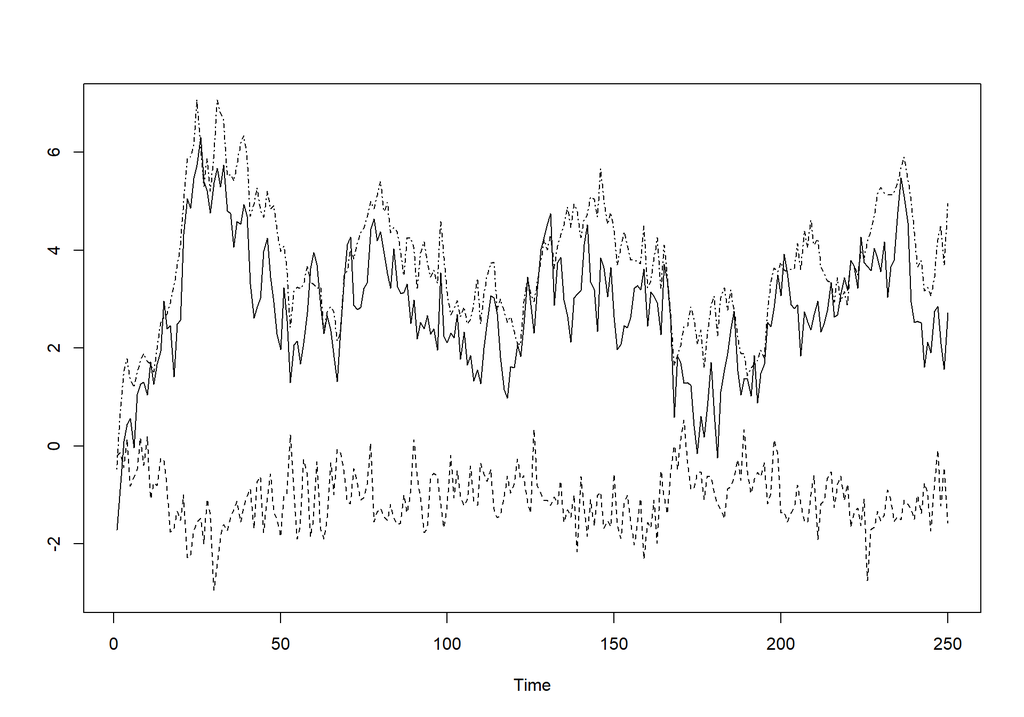

```r
set.seed(9)

e1 <- rnorm(250,0,0.5)
e2 <- rnorm(250,0,0.5)
e3 <- rnorm(250,0,0.5)

u1.ar1 <- arima.sim(model = list(ar=0.75), innov = e1, n = 250)
u2.ar1 <- arima.sim(model = list(ar=0.3), innov = e2, n = 250)

y3 <- cumsum(e3)
y1 <- 0.8*y3 + u1.ar1
y2 <- -0.3*y3 + u2.ar1


y.mat <- data.frame(y1,y2,y3)

# Figura 8.8
plot.ts(y1, lty = 1, ylim = c(-3,7), ylab = "")
lines(y2, lty = 2)
lines(y3, lty = 4)
```

A função do R ca.jo() estima as matrizes $\alpha$ e $\beta$, além das estatísticas de teste para os dois métodos.

A estimação do VEC é feita em duas etapas, na primeira se estima, por máxima verossimilhança, as relações de cointegração, e em seguida, com mínimos quadrados, os coeficientes dos termos determinísticos e de defasagem.

Nos resultados, $r=0$ equivale a hipótese de não existência de relações de cointegração, enquanto $r \leq i$ equivale à de i ou menos relações de cointegração.

Abaixo, a saída do teste do máximo autovalor:

```r
library(vars)
vecm <- ca.jo(y.mat, type = c("eigen"), ecdet = "const")

jo.results <- summary(vecm)
jo.results
```

```
#
# ######################
# # Johansen-Procedure #
# ######################
#
# Test type: maximal eigenvalue statistic (lambda max) , without linear trend and constant in cointegration
#
# Eigenvalues (lambda):
# [1] 3.357938e-01 1.410541e-01 4.949758e-02 7.842278e-19
#
# Values of teststatistic and critical values of test:
#
#            test 10pct  5pct  1pct
# r <= 2 |  12.59  7.52  9.24 12.97
# r <= 1 |  37.71 13.75 15.67 20.20
# r = 0  | 101.47 19.77 22.00 26.81
#
# Eigenvectors, normalised to first column:
# (These are the cointegration relations)
#
#              y1.l2       y2.l2      y3.l2   constant
# y1.l2     1.000000  1.00000000  1.0000000   1.000000
# y2.l2    23.739744 -0.01440361  0.9326373   0.508324
# y3.l2     5.521199 -0.83720628 -6.9751085  -4.804581
# constant  1.916051  0.31478225 25.5249365 -11.754289
#
# Weights W:
# (This is the loading matrix)
#
#             y1.l2       y2.l2        y3.l2      constant
# y1.d -0.002543326 -0.28362568  0.013102253 -5.359063e-18
# y2.d -0.037142149 -0.01269080 -0.004450528  4.293815e-19
# y3.d -0.003204754  0.04075187  0.013609744  8.093119e-18
```

```r
vect <- ca.jo(y.mat, type = c("trace"), ecdet = "const")

jo.results <- summary(vect)
jo.results
```

```
#
# ######################
# # Johansen-Procedure #
# ######################
#
# Test type: trace statistic , without linear trend and constant in cointegration
#
# Eigenvalues (lambda):
# [1] 3.357938e-01 1.410541e-01 4.949758e-02 7.842278e-19
#
# Values of teststatistic and critical values of test:
#
#            test 10pct  5pct  1pct
# r <= 2 |  12.59  7.52  9.24 12.97
# r <= 1 |  50.30 17.85 19.96 24.60
# r = 0  | 151.77 32.00 34.91 41.07
#
# Eigenvectors, normalised to first column:
# (These are the cointegration relations)
#
#              y1.l2       y2.l2      y3.l2   constant
# y1.l2     1.000000  1.00000000  1.0000000   1.000000
# y2.l2    23.739744 -0.01440361  0.9326373   0.508324
# y3.l2     5.521199 -0.83720628 -6.9751085  -4.804581
# constant  1.916051  0.31478225 25.5249365 -11.754289
#
# Weights W:
# (This is the loading matrix)
#
#             y1.l2       y2.l2        y3.l2      constant
# y1.d -0.002543326 -0.28362568  0.013102253 -5.359063e-18
# y2.d -0.037142149 -0.01269080 -0.004450528  4.293815e-19
# y3.d -0.003204754  0.04075187  0.013609744  8.093119e-18
```

Observe que as estatísticas de teste rejeitam as duas hipóteses nulas iniciais ($r=0$ e $r \leq 1$) a 1% de significância. Como se tem três variáveis, haverá no máximo 2 vetores de cointegração.

Resultado semelhante foi encontrado na estatística do traço.

Por padrão, a saída mostra tambem os vetores de cointegração normalizados para a primeira variável, uma transformação proposta por Johansen.

Para se estimar os demais coeficientes do modelo se utiliza a função cajorls() com base na quantidade de relações de cointegração.

```r
vecm.r2 <- cajorls(vecm, r = 2)
vecm.r2
```

```
# $rlm
#
# Call:
# lm(formula = substitute(form1), data = data.mat)
#
# Coefficients:
#         y1.d      y2.d      y3.d
# ect1    -0.28617  -0.04983   0.03755
# ect2    -0.05629  -0.88156  -0.07667
# y1.dl1  -0.22437  -0.10328   0.07510
# y2.dl1   0.08227  -0.80306   0.01229
# y3.dl1   0.07289  -0.05364  -0.16650
#
#
# $beta
#                ect1         ect2
# y1.l2     1.0000000 6.938894e-18
# y2.l2     0.0000000 1.000000e+00
# y3.l2    -0.8333508 2.676756e-01
# constant  0.3157532 6.741008e-02
```

A saída da função retorna não só os vetores com as relações de longo prazo (beta), assim como a matriz de coeficientes do modelo (rlm) e os termos de ajuste (ect), componentes de alpha.

Na seção correspondente aos vetores de cointegração (beta), se tem duas colunas, cada uma com um vetor de cointegração. Como estão normalizados, pode-se facilmente encontrar a contrapartida com os coeficientes do processo gerador.